# Modeling and Analysis

Cassandra Bayer

6/15/2018

Source the controller, wherein necessary packages and custom functions get read in. The controller also reads in the data and uses a cleaning function to get it in a place that we can work with it. I then separate out my cleaned data and prepare to work with it.

[output not shown]

[output not shown]

[output not shown]

[output not shown]

[output not shown]

[output not shown]

[output not shown]

[output not shown]

Before diving in, I’m curious to see the distribution of my data as well as the distribution of the older, messier data. Everyone likes an ego boost. After running the summary, since most of my variables are dummies, nothing is too surprising. I then compare it to the data as it was. As I suspeced, the qualitative data is not ideal for summary statistics or analysis. However, despite my cleaning, the summary is not incredibly helpful. I then make a quick set of barcharts to view the distribution of the data. One could also facet wrap and use ggplot functionality; however, since the graphs are only for personal eye-balling, base R graphics do the job.

```r
summary(census_train)
```

```
##       age            ageSq           male            female
##  Min.   : 0.00   Min.   :   0   Min.   :0.0000   Min.   :0.0000
##  1st Qu.:15.00   1st Qu.: 225   1st Qu.:0.0000   1st Qu.:0.0000
##  Median :33.00   Median :1089   Median :0.0000   Median :1.0000
##  Mean   :34.49   Mean   :1688   Mean   :0.4788   Mean   :0.5212
##  3rd Qu.:50.00   3rd Qu.:2500   3rd Qu.:1.0000   3rd Qu.:1.0000
##  Max.   :90.00   Max.   :8100   Max.   :1.0000   Max.   :1.0000
##
##  normalizedWageHr     foreignDad       foreignMom        foreign
##  Min.   :    0.00   Min.   :0.0000   Min.   :0.0000   Min.   :0.0000
##  1st Qu.:    0.00   1st Qu.:0.0000   1st Qu.:0.0000   1st Qu.:0.0000
##  Median :    0.00   Median :0.0000   Median :0.0000   Median :0.0000
##  Mean   :   56.43   Mean   :0.0947   Mean   :0.0947   Mean   :0.0947
##  3rd Qu.:    0.00   3rd Qu.:0.0000   3rd Qu.:0.0000   3rd Qu.:0.0000
##  Max.   :10298.00   Max.   :1.0000   Max.   :1.0000   Max.   :1.0000
##  NA's   :99695      NA's   :2813     NA's   :2813     NA's   :2813
##  wksWorkedPastYr     black            white           hispanic
##  Min.   : 0.00   Min.   :0.0000   Min.   :0.0000   Min.   :0.0000
##  1st Qu.: 0.00   1st Qu.:0.0000   1st Qu.:1.0000   1st Qu.:1.0000
##  Median : 8.00   Median :0.0000   Median :1.0000   Median :1.0000
##  Mean   :23.18   Mean   :0.1023   Mean   :0.8388   Mean   :0.9941
##  3rd Qu.:52.00   3rd Qu.:0.0000   3rd Qu.:1.0000   3rd Qu.:1.0000
##  Max.   :52.00   Max.   :1.0000   Max.   :1.0000   Max.   :1.0000
##
##    unemployed         blueCollar      whiteCollar      belowCollege
##  Min.   :0.000000   Min.   :0.0000   Min.   :0.0000   Min.   :0.0000
##  1st Qu.:0.000000   1st Qu.:0.0000   1st Qu.:1.0000   1st Qu.:1.0000
##  Median :0.000000   Median :0.0000   Median :1.0000   Median :1.0000
##  Mean   :0.000827   Mean   :0.1608   Mean   :0.8392   Mean   :0.8255
##  3rd Qu.:0.000000   3rd Qu.:0.0000   3rd Qu.:1.0000   3rd Qu.:1.0000
##  Max.   :1.000000   Max.   :1.0000   Max.   :1.0000   Max.   :1.0000
##
##     college        aboveCollege     aboveMasters        divorced
##  Min.   :0.0000   Min.   :0.0000   Min.   :0.00000   Min.   :0.0000
##  1st Qu.:0.0000   1st Qu.:0.0000   1st Qu.:0.00000   1st Qu.:0.0000
##  Median :0.0000   Median :0.0000   Median :0.00000   Median :0.0000
##  Mean   :0.1264   Mean   :0.0481   Mean   :0.00633   Mean   :0.0637
##  3rd Qu.:0.0000   3rd Qu.:0.0000   3rd Qu.:0.00000   3rd Qu.:0.0000
##  Max.   :1.0000   Max.   :1.0000   Max.   :1.00000   Max.   :1.0000
##
```

[output cut: 9 more lines]

```
##  Min.   :0.0000   Min.   :0.00000   Min.   :0.000000   Min.   :0.000
##  1st Qu.:0.0000   1st Qu.:0.00000   1st Qu.:0.000000   1st Qu.:0.000
##  Median :0.0000   Median :0.00000   Median :0.000000   Median :1.000
##  Mean   :0.2771   Mean   :0.03202   Mean   :0.004776   Mean   :0.518
##  3rd Qu.:1.0000   3rd Qu.:0.00000   3rd Qu.:0.000000   3rd Qu.:1.000
##  Max.   :1.0000   Max.   :1.00000   Max.   :1.000000   Max.   :1.000
##
##  whiteDivorcedM    blackDivorcedM     hispanicDivorcedM    over50k
##  Min.   :0.00000   Min.   :0.000000   Min.   :0.00000   Min.   :0.00000
##  1st Qu.:0.00000   1st Qu.:0.000000   1st Qu.:0.00000   1st Qu.:0.00000
##  Median :0.00000   Median :0.000000   Median :0.00000   Median :0.00000
##  Mean   :0.02207   Mean   :0.002356   Mean   :0.02516   Mean   :0.06206
##  3rd Qu.:0.00000   3rd Qu.:0.000000   3rd Qu.:0.00000   3rd Qu.:0.00000
##  Max.   :1.00000   Max.   :1.000000   Max.   :1.00000   Max.   :1.00000
##
```

```r
summary(full_train$dtMessy)
```

```
##       age        classOfWorker      industryRecode      occRecode
##  Min.   : 0.00   Length:199522      Length:199522      Length:199522
##  1st Qu.:15.00   Class :character   Class :character   Class :character
##  Median :33.00   Mode  :character   Mode  :character   Mode  :character
##  Mean   :34.49
##  3rd Qu.:50.00
##  Max.   :90.00
##
##      edu                wageHr        eduInLastWk
##  Length:199522      Min.   :   0.00   Length:199522
##  Class :character   1st Qu.:   0.00   Class :character
##  Mode  :character   Median :   0.00   Mode  :character
##                     Mean   :  55.43
##                     3rd Qu.:   0.00
##                     Max.   :9999.00
##
##  maritalStat        majorIndustry      majorOccCode          hispanic
##  Length:199522      Length:199522      Length:199522      Min.   :0.0000
##  Class :character   Class :character   Class :character   1st Qu.:1.0000
##  Mode  :character   Mode  :character   Mode  :character   Median :1.0000
##                                                           Mean   :0.9941
##                                                           3rd Qu.:1.0000
##                                                           Max.   :1.0000
##
##      sex             laborUnion        unemploymentReason
##  Length:199522      Length:199522      Length:199522
##  Class :character   Class :character   Class :character
##  Mode  :character   Mode  :character   Mode  :character
##
##
##
##
##  employmentStatus     capGains           capLoss
##  Length:199522      Length:199522      Length:199522
##  Class :character   Class :character   Class :character
##  Mode  :character   Mode  :character   Mode  :character
##
##
##
##
```

[output cut: 97 more lines]

```
##  Min.   :0.000000   Min.   :0.000     Min.   :0.00000   Min.   :0.000000
##  1st Qu.:0.000000   1st Qu.:0.000     1st Qu.:0.00000   1st Qu.:0.000000
##  Median :0.000000   Median :1.000     Median :0.00000   Median :0.000000
##  Mean   :0.004776   Mean   :0.518     Mean   :0.02207   Mean   :0.002356
##  3rd Qu.:0.000000   3rd Qu.:1.000     3rd Qu.:0.00000   3rd Qu.:0.000000
##  Max.   :1.000000   Max.   :1.000     Max.   :1.00000   Max.   :1.000000
##
##  hispanicDivorcedM
##  Min.   :0.00000
##  1st Qu.:0.00000
##  Median :0.00000
##  Mean   :0.02516
##  3rd Qu.:0.00000
##  Max.   :1.00000
##
```

```r
meltMissing <- full_train$missingPct
barchart <- barchart(meltMissing)
```

I then do the same at-a-glance review, but a bit differently for the continuous data. Here, rather than raw frequencies, I can see a better picture of the distribution of the data.

```r
# First I want to get a basic summary of my data. However, since my custom data is mostly binary, this is not
# helpful, nor intuitive. So I do that only for my integer data types.
intData <- select_if(census_train, is.integer)
summary(intData)
```

```
##       age            ageSq           male            female
##  Min.   : 0.00   Min.   :   0   Min.   :0.0000   Min.   :0.0000
##  1st Qu.:15.00   1st Qu.: 225   1st Qu.:0.0000   1st Qu.:0.0000
##  Median :33.00   Median :1089   Median :0.0000   Median :1.0000
##  Mean   :34.49   Mean   :1688   Mean   :0.4788   Mean   :0.5212
##  3rd Qu.:50.00   3rd Qu.:2500   3rd Qu.:1.0000   3rd Qu.:1.0000
##  Max.   :90.00   Max.   :8100   Max.   :1.0000   Max.   :1.0000
##
##  normalizedWageHr     foreignDad       foreignMom        foreign
##  Min.   :    0.00   Min.   :0.0000   Min.   :0.0000   Min.   :0.0000
##  1st Qu.:    0.00   1st Qu.:0.0000   1st Qu.:0.0000   1st Qu.:0.0000
##  Median :    0.00   Median :0.0000   Median :0.0000   Median :0.0000
##  Mean   :   56.43   Mean   :0.0947   Mean   :0.0947   Mean   :0.0947
##  3rd Qu.:    0.00   3rd Qu.:0.0000   3rd Qu.:0.0000   3rd Qu.:0.0000
##  Max.   :10298.00   Max.   :1.0000   Max.   :1.0000   Max.   :1.0000
##  NA's   :99695      NA's   :2813     NA's   :2813     NA's   :2813
##  wksWorkedPastYr     black            white           hispanic
##  Min.   : 0.00   Min.   :0.0000   Min.   :0.0000   Min.   :0.0000
##  1st Qu.: 0.00   1st Qu.:0.0000   1st Qu.:1.0000   1st Qu.:1.0000
##  Median : 8.00   Median :0.0000   Median :1.0000   Median :1.0000
##  Mean   :23.18   Mean   :0.1023   Mean   :0.8388   Mean   :0.9941
##  3rd Qu.:52.00   3rd Qu.:0.0000   3rd Qu.:1.0000   3rd Qu.:1.0000
##  Max.   :52.00   Max.   :1.0000   Max.   :1.0000   Max.   :1.0000
##
##    unemployed         blueCollar      whiteCollar      belowCollege
##  Min.   :0.000000   Min.   :0.0000   Min.   :0.0000   Min.   :0.0000
##  1st Qu.:0.000000   1st Qu.:0.0000   1st Qu.:1.0000   1st Qu.:1.0000
##  Median :0.000000   Median :0.0000   Median :1.0000   Median :1.0000
##  Mean   :0.000827   Mean   :0.1608   Mean   :0.8392   Mean   :0.8255
##  3rd Qu.:0.000000   3rd Qu.:0.0000   3rd Qu.:1.0000   3rd Qu.:1.0000
##  Max.   :1.000000   Max.   :1.0000   Max.   :1.0000   Max.   :1.0000
##
##     college        aboveCollege     aboveMasters        divorced
##  Min.   :0.0000   Min.   :0.0000   Min.   :0.00000   Min.   :0.0000
##  1st Qu.:0.0000   1st Qu.:0.0000   1st Qu.:0.00000   1st Qu.:0.0000
##  Median :0.0000   Median :0.0000   Median :0.00000   Median :0.0000
##  Mean   :0.1264   Mean   :0.0481   Mean   :0.00633   Mean   :0.0637
##  3rd Qu.:0.0000   3rd Qu.:0.0000   3rd Qu.:0.00000   3rd Qu.:0.0000
##  Max.   :1.0000   Max.   :1.0000   Max.   :1.00000   Max.   :1.0000
##
```

[output cut: 9 more lines]

```
##  Min.   :0.0000   Min.   :0.00000   Min.   :0.000000   Min.   :0.000
##  1st Qu.:0.0000   1st Qu.:0.00000   1st Qu.:0.000000   1st Qu.:0.000
##  Median :0.0000   Median :0.00000   Median :0.000000   Median :1.000
##  Mean   :0.2771   Mean   :0.03202   Mean   :0.004776   Mean   :0.518
##  3rd Qu.:1.0000   3rd Qu.:0.00000   3rd Qu.:0.000000   3rd Qu.:1.000
##  Max.   :1.0000   Max.   :1.00000   Max.   :1.000000   Max.   :1.000
##
##  whiteDivorcedM    blackDivorcedM     hispanicDivorcedM    over50k
##  Min.   :0.00000   Min.   :0.000000   Min.   :0.00000   Min.   :0.00000
##  1st Qu.:0.00000   1st Qu.:0.000000   1st Qu.:0.00000   1st Qu.:0.00000
##  Median :0.00000   Median :0.000000   Median :0.00000   Median :0.00000
##  Mean   :0.02207   Mean   :0.002356   Mean   :0.02516   Mean   :0.06206
##  3rd Qu.:0.00000   3rd Qu.:0.000000   3rd Qu.:0.00000   3rd Qu.:0.00000
##  Max.   :1.00000   Max.   :1.000000   Max.   :1.00000   Max.   :1.00000
##
```

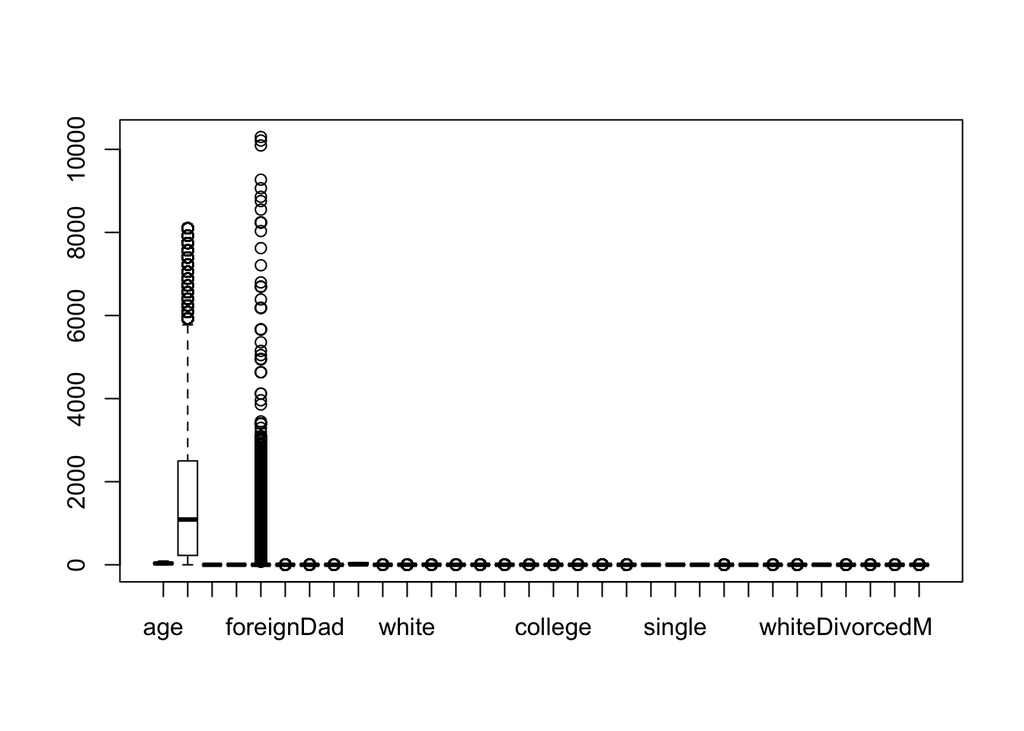

```r
boxplot(intData)
```

Lastly, I put it all together in one place. This serves as a gut check to the graphs and summaries I was seeing above.

```r
# For the rest of the data, I was to get an idea of frequencies.
meltedCensus <- melt(census_train)
```

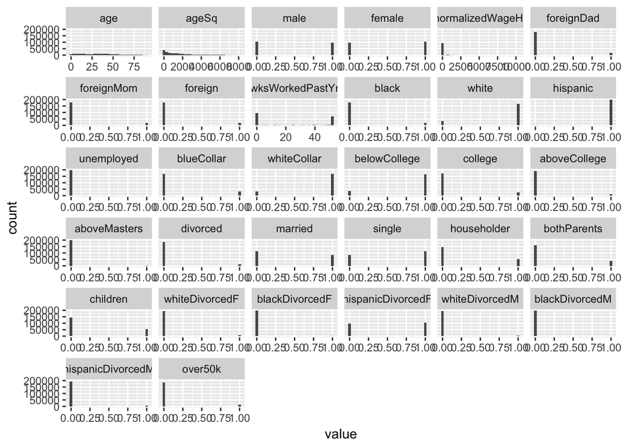

```r
ggplot(meltedCensus,aes(x = value)) +
    facet_wrap(~variable,scales = "free_x") +
    geom_histogram()
```

First, I want to look at the missing data in the original data; again, many of the columns I have decided to omit were riddled with missing data. Then, I want to get a sense of any missing data still remaining in the “clean” data I created. Using a standard `missmap`, I organize my data by any outstanding missing data. It doesn’t look too bad, but I can still weed out any remaining missing values. Although I could impute using the mean, the data is so large that the missing records be dropped should have a negligible effect. With more time, I would like to test the effect of dropping missing records.

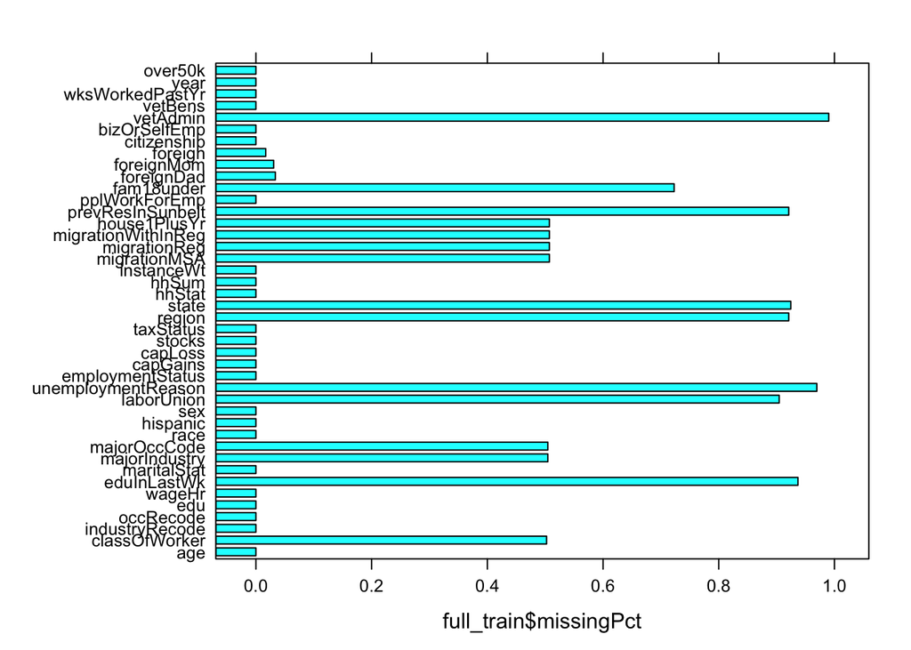

```r
meltedMissing <- melt(full_train$missingPct)
barchart(full_train$missingPct)
```

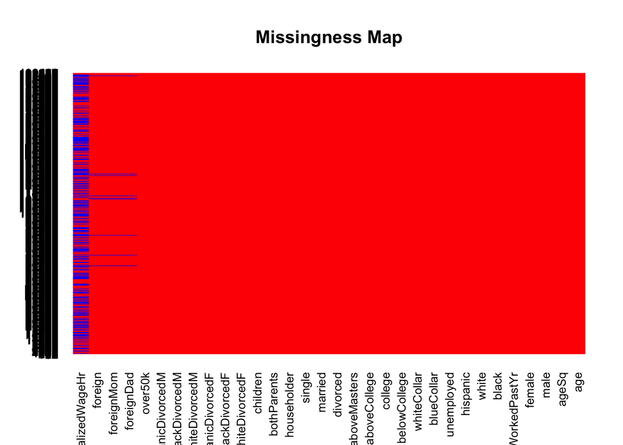

```r
missmap(census_train, col=c("blue", "red"), legend=FALSE)
```

Now that we know what’s missing, let’s drop missing values.

```r
census_train <- na.omit(census_train)
census_test <- na.omit(census_test)
```

Now I want to get a sense of how my variables are correlated. I suspect some covariance, but that’s expected given the nature of the dummy variables (where sex is female, it cnanot also be male; I would anticipate those to be perfectly inversely related). However, I’m interested to see if any of these variables correlate with variables outside of their binary counterparts.I’m seeing some interesting relationships, so I’d like to explore them more using some basic regression.

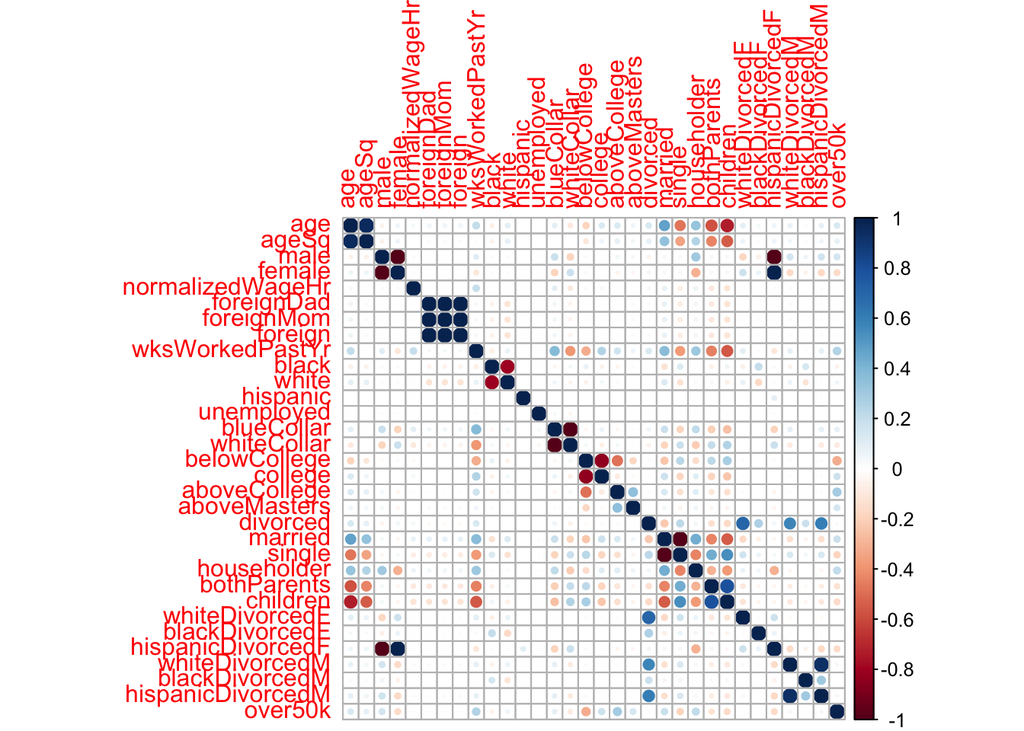

```r
corr <- cor(census_train)
corrplot(corr, method="circle")
```

This gives me a playground to do more work with variable selection. Given the time, this would be one technique I’d use as a gut check for feature selection when building a model.

```r
# runApp()
```

```r
lm <- glm(data = census_train,formula =  over50k ~ ., family=binomial(link= "logit"))
summary(lm)
```

```
##
## Call:
## glm(formula = over50k ~ ., family = binomial(link = "logit"),
##     data = census_train)
##
## Deviance Residuals:
##     Min       1Q   Median       3Q      Max
## -1.8342  -0.2755  -0.1014  -0.0072   3.9708
##
## Coefficients: (6 not defined because of singularities)
##                     Estimate Std. Error z value Pr(>|z|)
## (Intercept)       -8.310e+00  4.082e-01 -20.355  < 2e-16 ***
## age                1.685e-01  8.277e-03  20.355  < 2e-16 ***
## ageSq             -1.397e-03  8.496e-05 -16.442  < 2e-16 ***
## male               1.468e+00  4.047e-01   3.626 0.000287 ***
## female                    NA         NA      NA       NA
## normalizedWageHr  -9.325e-05  4.247e-05  -2.196 0.028120 *
## foreignDad        -4.541e-01  6.517e-02  -6.968 3.21e-12 ***
## foreignMom                NA         NA      NA       NA
## foreign                   NA         NA      NA       NA
## wksWorkedPastYr    4.328e-02  1.329e-03  32.557  < 2e-16 ***
## black             -6.174e-01  1.240e-01  -4.980 6.36e-07 ***
## white              2.289e-02  9.367e-02   0.244 0.806936
## hispanic          -2.918e-02  2.031e-01  -0.144 0.885755
## unemployed        -1.627e+01  1.070e+03  -0.015 0.987872
## blueCollar         3.724e-02  3.636e-02   1.024 0.305761
## whiteCollar               NA         NA      NA       NA
## belowCollege      -2.309e+00  4.601e-02 -50.177  < 2e-16 ***
## college           -8.680e-01  4.687e-02 -18.517  < 2e-16 ***
## aboveCollege              NA         NA      NA       NA
## aboveMasters       4.840e-01  1.023e-01   4.730 2.25e-06 ***
## divorced           3.521e-01  3.982e-01   0.884 0.376585
## married            2.062e-01  5.215e-02   3.954 7.69e-05 ***
## single                    NA         NA      NA       NA
## householder        3.052e-01  4.215e-02   7.240 4.48e-13 ***
## bothParents        9.343e+00  1.111e+02   0.084 0.932983
## children          -1.140e+01  1.111e+02  -0.103 0.918234
## whiteDivorcedF     1.051e-02  4.034e-01   0.026 0.979214
## blackDivorcedF     5.041e-01  4.671e-01   1.079 0.280497
## hispanicDivorcedF  1.783e-01  4.059e-01   0.439 0.660426
## whiteDivorcedM    -1.789e-01  4.110e-01  -0.435 0.663379
## blackDivorcedM    -4.310e-01  5.365e-01  -0.803 0.421723
## hispanicDivorcedM -2.195e-01  4.830e-01  -0.454 0.649474
## ---
## Signif. codes:  0 '***' 0.001 '**' 0.01 '*' 0.05 '.' 0.1 ' ' 1
##
## (Dispersion parameter for binomial family taken to be 1)
##
##     Null deviance: 43703  on 98478  degrees of freedom
## Residual deviance: 27943  on 98453  degrees of freedom
## AIC: 27995
##
## Number of Fisher Scoring iterations: 18
```

```r
probs <- predict(lm,type = "response")
pred <- ifelse(probs > 0.5, "Over 50k", "Under 50k")
table(pred)
```

```
## pred
##  Over 50k Under 50k
##      2115     96364
```

Using a stepwise model, I find the ideal formula given the variables that I have, which selects only the variables of importance. Since there are still many variables, I suspect overfitting. I would also explore the “Leave One Out” step to find the optimal point at which my model had enough predictive power before introducing variable covariance.

```r
# I've commented this out becuase it is so performance intensive. However, I have used the call it returns
# below in lm2.
# step.model <- stepAIC(lm, direction = "both",
#                       trace = FALSE)
# summary(step.model)

lm2 <- glm(formula = over50k ~ ageSq + male + normalizedWageHr + foreignDad +
    wksWorkedPastYr + black + unemployed + belowCollege + college +
    aboveMasters + married + householder + bothParents + blackDivorcedM +
    hispanicDivorcedM, data = census_train, family = binomial(link = "logit"))

summary(lm2)
```

```
##
## Call:
## glm(formula = over50k ~ ageSq + male + normalizedWageHr + foreignDad +
##     wksWorkedPastYr + black + unemployed + belowCollege + college +
##     aboveMasters + married + householder + bothParents + blackDivorcedM +
##     hispanicDivorcedM, family = binomial(link = "logit"), data = census_train)
##
## Deviance Residuals:
##     Min       1Q   Median       3Q      Max
## -2.1001  -0.2818  -0.1064  -0.0128   3.9839
##
## Coefficients:
##                     Estimate Std. Error z value Pr(>|z|)
## (Intercept)       -4.791e+00  9.068e-02 -52.831  < 2e-16 ***
## ageSq              3.095e-04  1.270e-05  24.374  < 2e-16 ***
## male               1.097e+00  4.142e-02  26.483  < 2e-16 ***
## normalizedWageHr  -7.882e-05  4.255e-05  -1.852 0.063988 .
## foreignDad        -4.520e-01  5.878e-02  -7.689 1.48e-14 ***
## wksWorkedPastYr    5.383e-02  1.305e-03  41.243  < 2e-16 ***
## black             -5.610e-01  7.962e-02  -7.046 1.84e-12 ***
## unemployed        -1.136e+01  8.850e+01  -0.128 0.897879
## belowCollege      -2.401e+00  4.463e-02 -53.791  < 2e-16 ***
## college           -9.380e-01  4.614e-02 -20.327  < 2e-16 ***
## aboveMasters       4.761e-01  1.016e-01   4.687 2.77e-06 ***
## married            3.445e-01  4.452e-02   7.738 1.01e-14 ***
## householder        4.575e-01  4.042e-02  11.319  < 2e-16 ***
## bothParents       -3.622e+00  1.003e+00  -3.613 0.000303 ***
## blackDivorcedM    -3.478e-01  3.569e-01  -0.974 0.329842
## hispanicDivorcedM  3.053e-01  8.462e-02   3.608 0.000309 ***
## ---
## Signif. codes:  0 '***' 0.001 '**' 0.01 '*' 0.05 '.' 0.1 ' ' 1
##
## (Dispersion parameter for binomial family taken to be 1)
##
##     Null deviance: 43703  on 98478  degrees of freedom
## Residual deviance: 28509  on 98463  degrees of freedom
## AIC: 28541
##
## Number of Fisher Scoring iterations: 13
```

In fact, running a quick test for false R^2s, my McFadden test shows that there is little difference between the two models that I have constructed. I also run an likelihood ratio test to check the goodness of fit between the two models. At this point, I’ve already discounted lm1, but I use it as a baseline from which to compare lm2.

```r
pR2(lm2)
```

```
##           llh       llhNull            G2      McFadden          r2ML
## -1.425452e+04 -2.185125e+04  1.519346e+04  3.476566e-01  1.429691e-01
##          r2CU
##  3.989201e-01
```

```r
pR2(lm)
```

```
##           llh       llhNull            G2      McFadden          r2ML
## -1.397156e+04 -2.185125e+04  1.575938e+04  3.606060e-01  1.478800e-01
##          r2CU
##  4.126228e-01
```

```r
anova(lm, lm2, test="LRT")
```

```
## Analysis of Deviance Table
##
## Model 1: over50k ~ age + ageSq + male + female + normalizedWageHr + foreignDad +
##     foreignMom + foreign + wksWorkedPastYr + black + white +
##     hispanic + unemployed + blueCollar + whiteCollar + belowCollege +
##     college + aboveCollege + aboveMasters + divorced + married +
##     single + householder + bothParents + children + whiteDivorcedF +
##     blackDivorcedF + hispanicDivorcedF + whiteDivorcedM + blackDivorcedM +
##     hispanicDivorcedM
## Model 2: over50k ~ ageSq + male + normalizedWageHr + foreignDad + wksWorkedPastYr +
##     black + unemployed + belowCollege + college + aboveMasters +
##     married + householder + bothParents + blackDivorcedM + hispanicDivorcedM
##   Resid. Df Resid. Dev  Df Deviance  Pr(>Chi)
## 1     98453      27943
## 2     98463      28509 -10  -565.92 < 2.2e-16 ***
## ---
## Signif. codes:  0 '***' 0.001 '**' 0.01 '*' 0.05 '.' 0.1 ' ' 1
```

For better or for worse, I’ve decided to stick with lm2. At this point, I’m curious about it’s real predictive power. So, at this point, I apply the model to my test data. I extract the classification error from my model to back out its accuracy. I’m pleasantly surprised that the model has 94.7% accuracy.

```r
predResults <- predict(lm2, newdata=census_test,type='response')
predResults <- ifelse(predResults > 0.5,1,0)

classificationError <- mean(predResults != census_test$over50k, na.rm = T)
print(paste('Accuracy',1-classificationError))
```

```
## [1] "Accuracy 0.947086498706695"
```

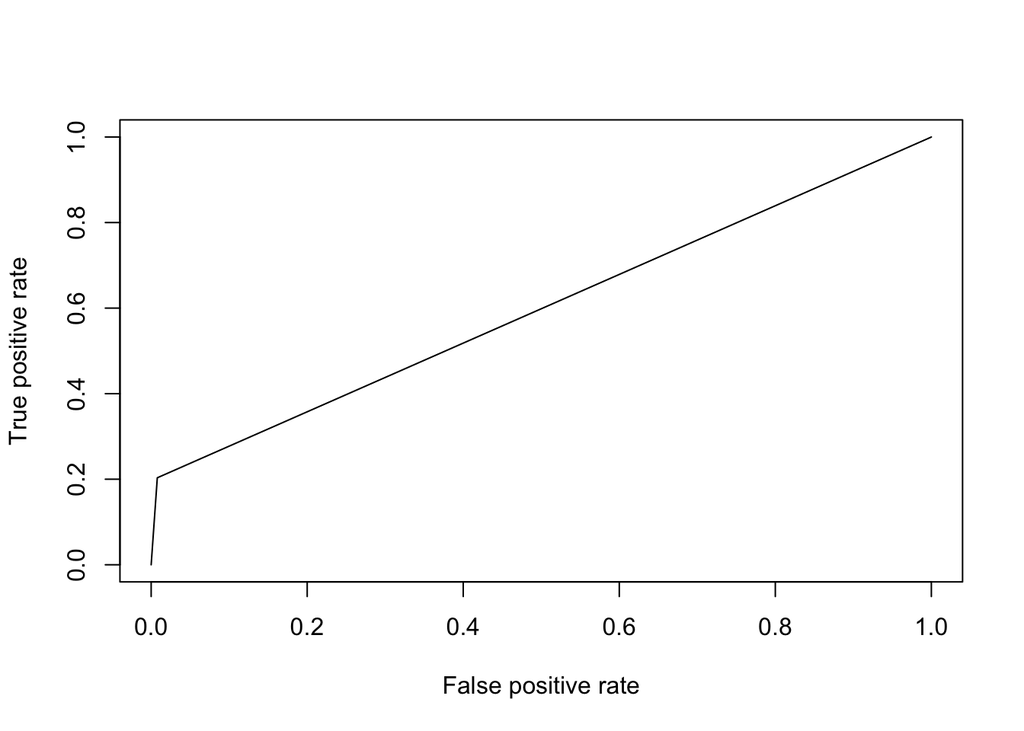

```r
predLm <- prediction(predResults, census_test$over50k)
prf <- performance(predLm, measure = "tpr", x.measure = "fpr")
plot(prf)
```

```r
auc <- performance(performance, measure = "auc")
```

[output not shown]

```r
auc <- auc@y.values[[1]]
```

[output not shown]

```r
auc
```

[output not shown]

However, I wonder if I could do better. Naturally, I turn to SVM, or what I deem to be to the closest thing to wizardry I’ll ever perform. I use the same variables in my model as my call from the step model.

```r
svm <- svm(over50k ~ ageSq + male + normalizedWageHr + foreignDad +
    wksWorkedPastYr + black + unemployed + belowCollege + college +
    aboveMasters + married + householder + bothParents + blackDivorcedM +
    hispanicDivorcedM, data = census_train)

svmPred_train <- predict(svm, census_train)
svmPrediction <- prediction(svmPred_train, census_test$over50k)
```

[output not shown]

```r
table(svmPred_train)
```

[output not shown]

[output cut: 14020 more lines]

[output not shown]

```r
table(svmPrediction)
```

[output not shown]

```r
error_lm <- lm2$residuals
lm2_error <- sqrt(mean(error_lm^2))

error_svm <- census_train$over50k - svmPred
```

[output not shown]

```r
svm_error <- sqrt(mean(error_svm^2))
```

[output not shown]

```r
table(svm_error, lm2_error)
```

[output not shown]

```r
table(pred)
```

```
## pred
##  Over 50k Under 50k
##      2115     96364
```

```r
tree <- rpart(over50k ~ ageSq + male + normalizedWageHr + foreignDad +
    wksWorkedPastYr + black + unemployed + belowCollege + college +
    aboveMasters + married + householder + bothParents + blackDivorcedM +
    hispanicDivorcedM, data = census_train, method = "class")
summary(tree)
```

```
## Call:
## rpart(formula = over50k ~ ageSq + male + normalizedWageHr + foreignDad +
##     wksWorkedPastYr + black + unemployed + belowCollege + college +
##     aboveMasters + married + householder + bothParents + blackDivorcedM +
##     hispanicDivorcedM, data = census_train, method = "class")
##   n= 98479
##
##           CP nsplit rel error    xerror       xstd
## 1 0.01689944      0 1.0000000 1.0000000 0.01282289
## 2 0.01000000      5 0.9155028 0.9189944 0.01232327
##
## Variable importance
##    belowCollege         college            male wksWorkedPastYr
##              31              27              14              10
##           ageSq     householder    aboveMasters         married
##               9               6               2               1
##
## Node number 1: 98479 observations,    complexity param=0.01689944
##   predicted class=0  expected loss=0.05816468  P(node) =1
##     class counts: 92751  5728
##    probabilities: 0.942 0.058
##   left son=2 (81760 obs) right son=3 (16719 obs)
##   Primary splits:
##       belowCollege    < 0.5    to the right, improve=1085.3330, (0 missing)
##       wksWorkedPastYr < 47.5   to the left,  improve= 726.0076, (0 missing)
##       householder     < 0.5    to the left,  improve= 517.4160, (0 missing)
##       ageSq           < 870.5  to the left,  improve= 435.1388, (0 missing)
##       married         < 0.5    to the left,  improve= 354.0546, (0 missing)
##   Surrogate splits:
##       college          < 0.5    to the left,  agree=0.954, adj=0.731, (0 split)
##       aboveMasters     < 0.5    to the left,  agree=0.836, adj=0.035, (0 split)
##       normalizedWageHr < 2407.5 to the left,  agree=0.830, adj=0.000, (0 split)
##
## Node number 2: 81760 observations
##   predicted class=0  expected loss=0.02459638  P(node) =0.8302278
##     class counts: 79749  2011
##    probabilities: 0.975 0.025
##
## Node number 3: 16719 observations,    complexity param=0.01689944
##   predicted class=0  expected loss=0.2223219  P(node) =0.1697722
```

[output cut: 69 more lines]

```
##       householder  < 0.5    to the left,  improve= 22.01554, (0 missing)
##   Surrogate splits:
##       aboveMasters     < 0.5    to the left,  agree=0.697, adj=0.163, (0 split)
##       ageSq            < 4970.5 to the left,  agree=0.641, adj=0.006, (0 split)
##       normalizedWageHr < 3083.5 to the left,  agree=0.639, adj=0.001, (0 split)
##
## Node number 62: 3107 observations
##   predicted class=0  expected loss=0.394271  P(node) =0.03154987
##     class counts:  1882  1225
##    probabilities: 0.606 0.394
##
## Node number 63: 1758 observations
##   predicted class=1  expected loss=0.3623436  P(node) =0.01785152
##     class counts:   637  1121
##    probabilities: 0.362 0.638
```

```r
predTree <- predict(tree, newdata = census_test, type= "class")

table(predTree, census_test$over50k)
```

```
##
## predTree     0     1
##        0 45972  2266
##        1   324   537
```

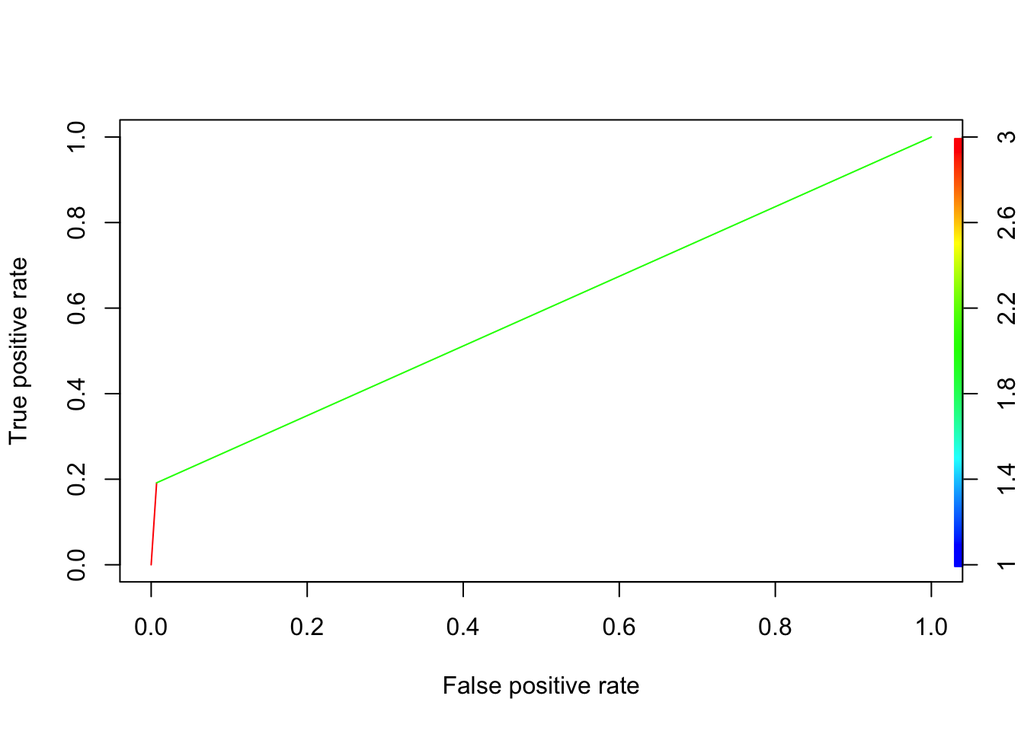

```r
roc_pred <- prediction(as.numeric(predTree), census_test$over50k)
plot(performance(roc_pred, measure="tpr", x.measure="fpr"), colorize=TRUE)
```

## Analysis and final write up

Given the output, I found that:

The data highlight a story of single parents, often of color, who are struggling to make a living wage to support themselves, or themselves and a family. Yet, I believe that this limited inspection does not do justice to the multi-faceted narrative. I believe build a comprehensive model to extrapolate meaningful analysis, one would have to pull in many other data sets to get at the root of causal influence on income and reduce omitted variable biases.

Yet, it is worth noting that the data was not normally distributed. Most of the data recorded was by respondents who in fact earned less than 50k, which points to the fact that this may not be a representative sample. So, while we can say these factors are strong predicitors amongst those in this sample, we cannot apply it to the population. Moving forward, I would want to weight the data given the normal demographic spread we’d see in the world.

## Challenges

I would have also liked to create more interaction variables. I know that the variables to not meet the assumption of independence and thusly muddy up the findings. In hindsight, and given more time, I would have constructed the model very differently. However, as an explatory first pass I was interested in the findings.